# Exploratory Data Analysis

## Line plots

### Total Detected Victims over time

This plot visualizes the total number of detected victims over time using the temporal dataset.

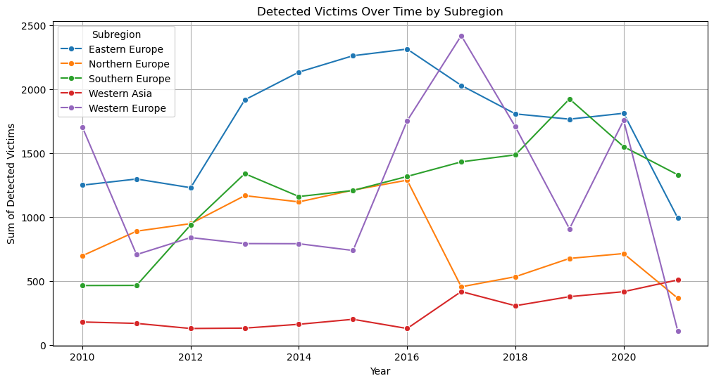

```python
# Sum of detected victims in each subregion per year
data_summary = timedf.groupby(['Year', 'Subregion'])['Detected_victims'].sum().reset_index()

# line plot:
plt.figure(figsize=(12, 6))
sns.lineplot(data=data_summary, x='Year', y='Detected_victims', hue='Subregion', marker='o')
xticks = range(int(data_summary['Year'].min()), int(data_summary['Year'].max()) + 1, 2)
plt.xticks(ticks=xticks)
plt.title('Detected Victims Over Time by Subregion')
plt.xlabel('Year')
plt.ylabel('Sum of Detected Victims')
plt.legend(title='Subregion')
plt.grid(True)
plt.show()
```

### Detected Victims per 100 Citizens per Subregion over time

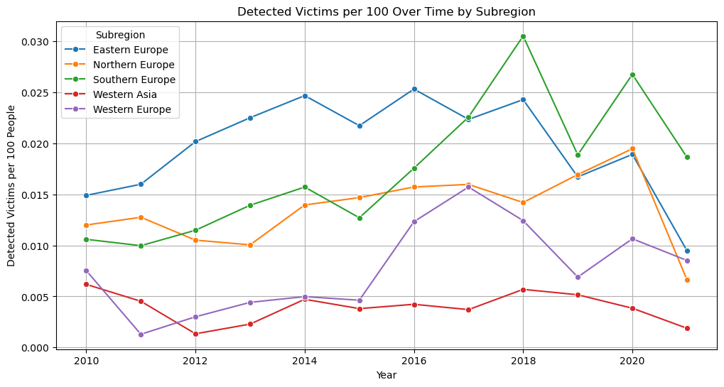

```python
# Sum of detected victims in each subregion per year
per100 = timedf.groupby(['Year', 'Subregion'])['Detections_per_100'].sum().reset_index()

# line plot:
plt.figure(figsize=(12, 6))
sns.lineplot(data=per100, x='Year', y='Detections_per_100', hue='Subregion', marker='o')
xticks = range(int(data_summary['Year'].min()), int(data_summary['Year'].max()) + 1, 2)
plt.xticks(ticks=xticks)
plt.title('Detected Victims per 100 Over Time by Subregion')
plt.xlabel('Year')
plt.ylabel('Detected Victims per 100 People')
plt.legend(title='Subregion')
plt.grid(True)
plt.show()
```

In contrast to the previous plot, this one shows the trends in the standardized rate of detected human trafficking victims per country per year, represented as the number of detected victims per 100 population. This plot shows that in recent years, countries in Southern Europe have surpassed all others in the number of victims they detected per 100 population.

### Detected Victims by Country, grouped by Subregion

```
No artists with labels found to put in legend.  Note that artists whose label start with an underscore are ignored when legend() is called with no argument.
```

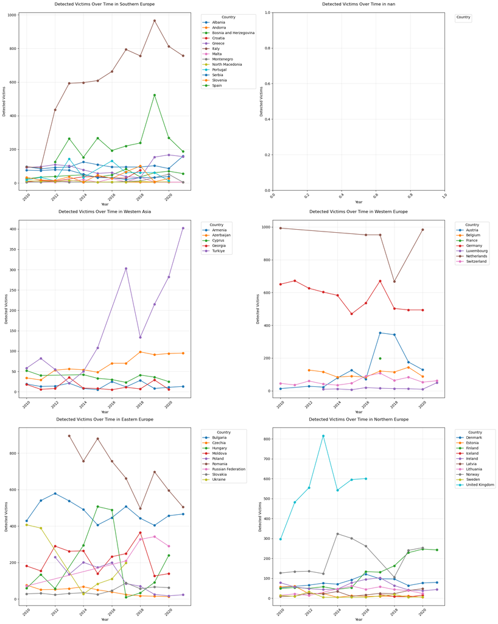

```python
import matplotlib.pyplot as plt
import seaborn as sns

# create figure with 5 subplots
fig, axes = plt.subplots(3, 2, figsize=(20, 25))
axes = axes.flatten()

# create a plot for each of the five subregions
subregions = timedf['Subregion'].unique()
for idx, subregion in enumerate(subregions):
    # filter data for the current subregion
    subregion_data = timedf[timedf['Subregion'] == subregion]

    # plot line plot
    ax = axes[idx]
    for country in subregion_data['Country'].unique():
        country_data = subregion_data[subregion_data['Country'] == country]
        ax.plot(country_data['Year'], country_data['Detected_victims'],
                label=country, marker='o')

    # Customize subplots
    ax.set_title(f'Detected Victims Over Time in {subregion}', pad=20)
    ax.set_xlabel('Year')
    ax.set_ylabel('Detected Victims')
    ax.grid(True, alpha=0.3)

    # logistics
    ax.tick_params(axis='x', rotation=45)
    ax.legend(bbox_to_anchor=(1.05, 1), loc='upper left', title='Country')

if len(subregions) < 6:
    fig.delaxes(axes[5])

# adjust layout to prevent overlap
plt.tight_layout()
plt.show()
```

This plot shows that interestingly, each subregion has one country that stands out compared to the others with much higher relative counts of detected victims of human trafficking. The outlier country in Southern Europe is Italy, in Western Asia it’s Turkey, in Western Europe it’s the Netherlands, in Eastern Europe it’s Romania, and in Northern Europe it’s the UK, but the data reported by the UK stops after 2016. The Netherlands appears to be the country with the highest counts of detected victims over time.

### Tier over time by Subregion

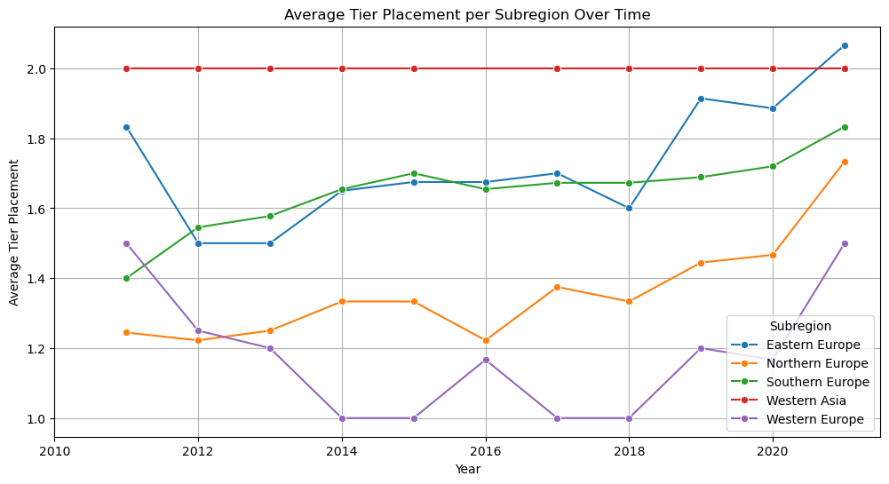

```python
tiersub = timedf.groupby(['Year', 'Subregion'])['Tier'].mean().reset_index()

# line plot:
plt.figure(figsize=(12, 6))
sns.lineplot(data=tiersub, x='Year', y='Tier', hue='Subregion', marker='o')
xticks = range(int(tiersub['Year'].min()), int(tiersub['Year'].max()) + 1, 2)
plt.xticks(ticks=xticks)
plt.title('Average Tier Placement per Subregion Over Time')
plt.xlabel('Year')
plt.ylabel('Average Tier Placement')
plt.legend(title='Subregion')
plt.grid(True)
plt.show()
```

### GDP per Capita over time by Subregion

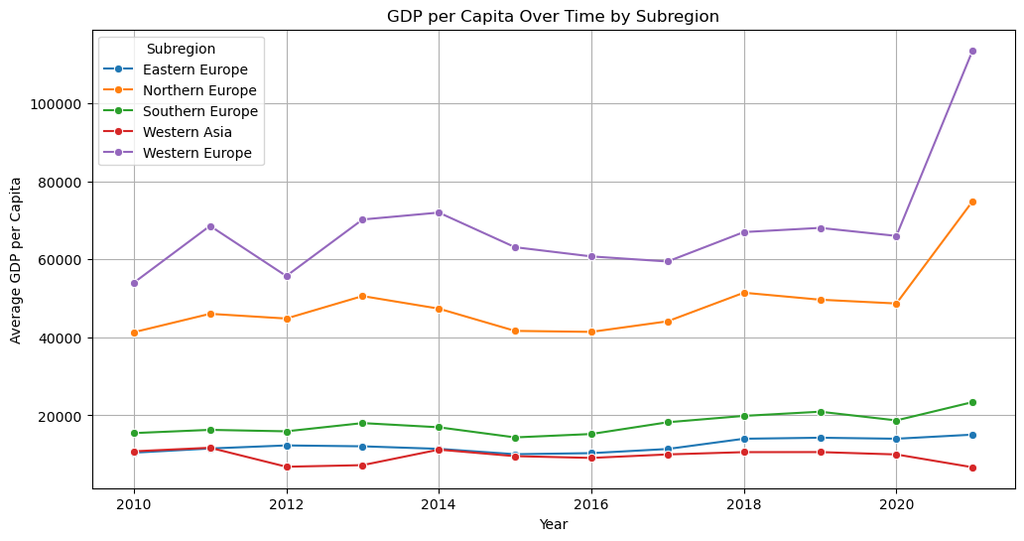

```python
# Group by Year and Subregion to calculate average GDP
data_gdp = timedf.groupby(['Year', 'Subregion'])['GDP_per_capita'].mean().reset_index()

# Line plot
plt.figure(figsize=(12, 6))
sns.lineplot(data=data_gdp, x='Year', y='GDP_per_capita', hue='Subregion', marker='o')
plt.title('GDP per Capita Over Time by Subregion')
plt.xlabel('Year')
plt.ylabel('Average GDP per Capita')
plt.legend(title='Subregion')
plt.grid(True)
plt.show()
```

This plot shows that the the GDP per capita is substantially higher in Western and Northern Europe than the other subregions, and especially the highest in Western Europe, with a noticeable increase in recent years.

## Bar charts

### Tier placements in 2024

This plot visualizes the breakdown of countries in Tier placements in the USDS’s 2024 Trafficking in Persons report. As a reminder:

- Tier 1 (1): countries that fully comply with the Trafficking Victim Protection Act’s (TVPA) minimum standards
- Tier 2 (2): countries that do not fully meet the TVPA’s minimum standards but are making significant efforts to
- Tier 2 Watchlist (2.2): countries in Tier 2 that also are either:
  - experiencing an increase in human trafficking prevalence that they are not proportionally responding to, OR
  - failing to provide evidence of increasing efforts
- Tier 3 (3): countries that do not fully meet the TVPA’s minimum standards and are not making significant efforts to do so.

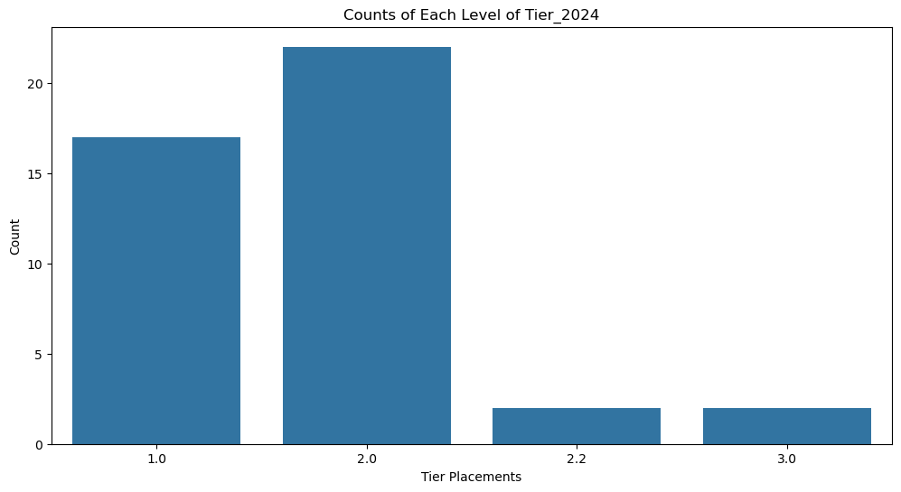

```python
# convert Tier_2024 to categorical
df['Tier_2024'] = df['Tier_2024'].astype('category')

plt.figure(figsize=(12, 6))
sns.countplot(data=df, x='Tier_2024')
plt.xlabel('Tier Placements')
plt.ylabel('Count')
plt.title('Counts of Each Level of Tier_2024')
plt.show()
```

This shows that the majority of countries in Europe are on Tier 2, and the second most are in Tier 1. Tier 2 Watchlist and Tier 3 both contain very few country observations in 2024.

### Convictions and Prosecution totals by Subregion

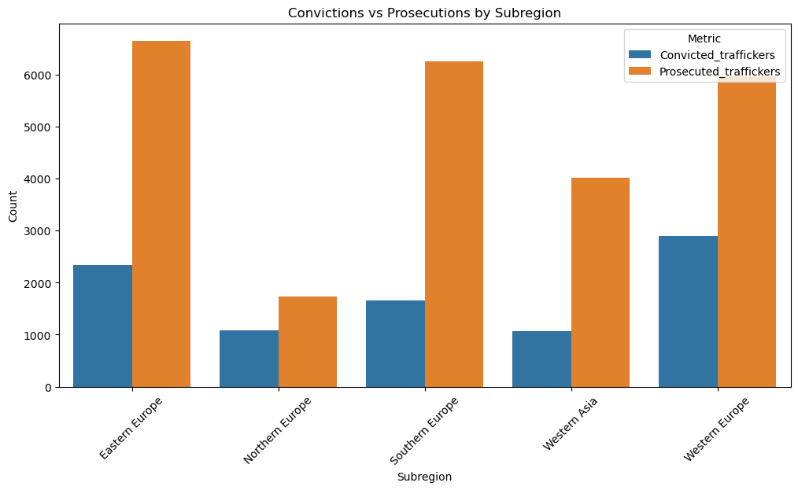

```python
# group by Subregion to sum convictions and prosecutions
sub = timedf.groupby('Subregion')[['Convicted_traffickers', 'Prosecuted_traffickers']].sum().reset_index()

# Melt the data for easier plotting
sub_melted = sub.melt(id_vars='Subregion',
                                                  value_vars=['Convicted_traffickers', 'Prosecuted_traffickers'],
                                                  var_name='Metric', value_name='Count')

# Bar plot
plt.figure(figsize=(12, 6))
sns.barplot(data=sub_melted, x='Subregion', y='Count', hue='Metric')
plt.title('Convictions vs Prosecutions by Subregion')
plt.xlabel('Subregion')
plt.ylabel('Count')
plt.xticks(rotation=45)
plt.show()
```

This plot shows that the ratio of convicted traffickers over prosecuted traffickers is highest in Northern Europe, where there is a smaller gap between the counts of the two values. However, it is imperative to recognize the scale of the counts here– Northern Europe has far fewer cases of prosecuted traffickers. This may reflect a poorer job of law enforcement in detecting traffickrs, or that there are simply fewer traffickers in this subregion.

### Tier by Prostitution Policy

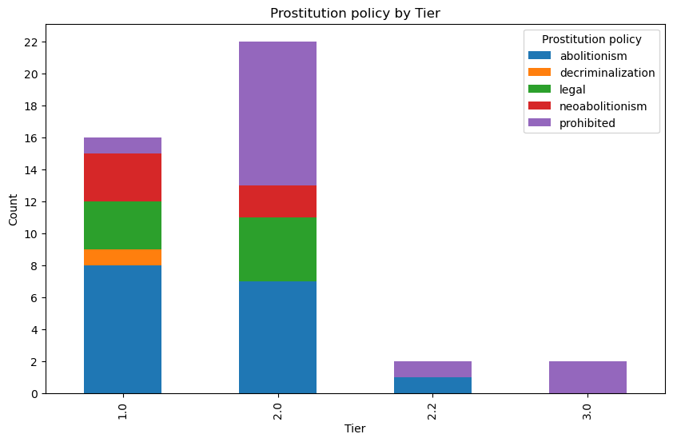

```python
# crosstab to count occurrences
crosstab = pd.crosstab(df['Tier_2024'], df['prostitution_policy'])

# stacked bar chart
crosstab.plot(kind='bar', stacked=True, figsize=(10, 6))

plt.title('Prostitution policy by Tier')
plt.xlabel('Tier')
plt.ylabel('Count')
plt.legend(title='Prostitution policy')
# set customize y axis tick intervals:
max_y = crosstab.values.sum(axis=1).max()
plt.yticks(np.arange(0, max_y + 2, 2))
plt.show()
```

This stacked bar chart shows that few countries in Tier 1 have prohibited prostitution policy, whereas this policy constitutes a larger share in the lower Tiers.

### Tier by Nonpunishment Policy

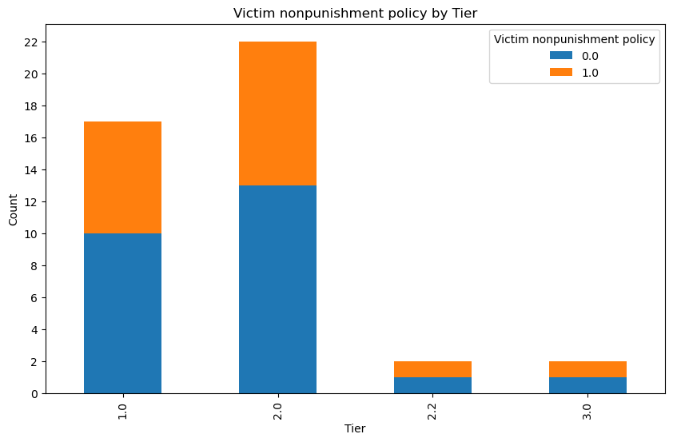

```python
# crosstab to count occurrences
crosstab = pd.crosstab(df['Tier_2024'], df['Nonpunishment_policy_after2021'])

# stacked bar chart
crosstab.plot(kind='bar', stacked=True, figsize=(10, 6))

plt.title('Victim nonpunishment policy by Tier')
plt.xlabel('Tier')
plt.ylabel('Count')
plt.legend(title='Victim nonpunishment policy')
max_y = crosstab.values.sum(axis=1).max()
plt.yticks(np.arange(0, max_y + 2, 2))
plt.show()
```

There appears to be no noticeable difference in victim nonpunishment policy between Tiers.

### Tier Placements 2024 Breakdown by Subregion

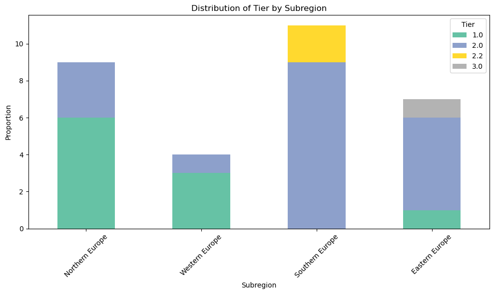

```python
# Create a pivot table for the counts
df['Tier_2024'] = pd.to_numeric(df['Tier_2024'], errors='coerce')
df_cleaned = df.dropna(subset=['Tier_2024']).copy()
df_cleaned = df_cleaned[df_cleaned['Subregion'] != "Western Asia"].copy()

# order Subregion levels
subregion_order = ['Northern Europe', 'Western Europe', 'Southern Europe', 'Eastern Europe']
df_cleaned['Subregion'] = pd.Categorical(df_cleaned['Subregion'], categories=subregion_order, ordered=True)

# create pivoy table
tier_pivot = pd.crosstab(df_cleaned['Subregion'], df_cleaned['Tier_2024'])

# stacked bar chart
tier_pivot.plot(kind='bar', stacked=True, figsize=(10, 6), colormap='Set2')

plt.title('Distribution of Tier by Subregion')
plt.xlabel('Subregion')
plt.ylabel('Proportion')
plt.legend(title='Tier')
plt.xticks(rotation=45)
plt.tight_layout()
plt.show()
```